# Session 4

# Data Visualisation

### (re)Sources

[figure not shown]

### Why visualise data?

- *understand*, explore
- *communicate*, explain, demonstrate

### Anscombe’s quartet

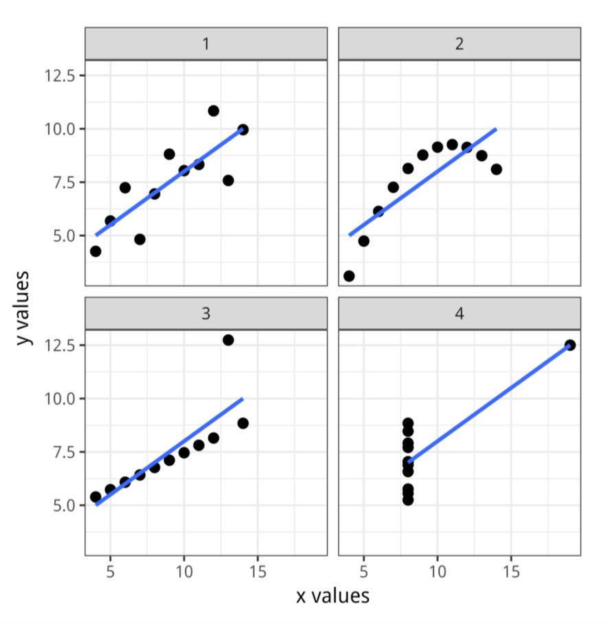

## ggplot2

Setup:

```r
library(tidyverse)
library(ggplot2)
```

“The Layered Grammar of Graphics”

http://vita.had.co.nz/papers/layered-grammar.pdf.

#### Why `ggplot`?

- More elegant & compact code than R base graphics
- Very powerful for exploratory data analysis
- Follows a grammar, just like any language.
- It defines basic components that make up a sentence.

### Grammar

The general call for `ggplot2` looks like this:

```r
# Not run
ggplot(data=, aes(x=, y=), color=, size=,) + geom_xxxx()+geom_yyyy()
```

The *grammar* involves some basic components:

1. **Data**: a data.frame
2. **Aes**thetics: How your data are represented visually, aka its “mapping”. Which variables are shown on x, y axes, as well as color, size, shape, etc.
3. **Geom**etry: The geometric objects in a plot – points, lines, polygons, etc. The key to understanding `ggplot2` is thinking about a figure in layers: just like you might do in an image editing program like Photoshop, Illustrator, or Inkscape.

```r
gap <- read.csv("data/gapminder-FiveYearData.csv", stringsAsFactors = F)
```

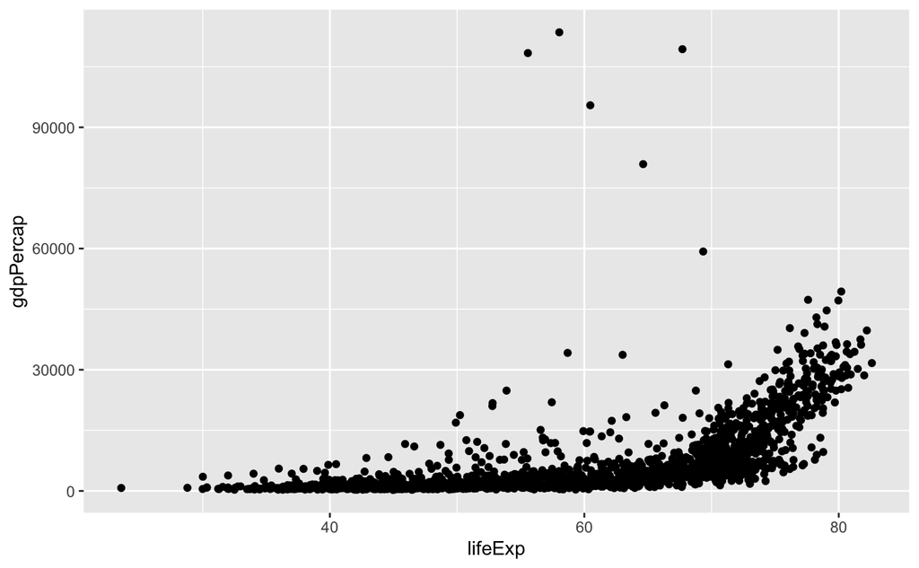

```r
ggplot(data = gap, aes(y = gdpPercap, x = lifeExp)) +
  geom_point()
```

## Aesthetic mappings

1. tidy data
2. a mapping
3. geometric layers
4. co-ordinates
5. scales
6. labels and guides
- Aesthetic mappings relate variables in your data to points, colours, shapes etc. in the figure.
- Step 1. tell ggplot what the data is
- Step 2. tell ggplot how the variables map to the plot’s aesthetics
- Step 3. tell ggplot what kind of plot you want to make with the data and the mappings

## Basic template

```r
#THIS WON'T RUN
plot <- ggplot(data = <data>,
               mapping = aes(<aesthetic> = <variable>,
                             <aesthetic> = <variable>...)) +
  geom_<type>(<...>) +
  scale_<mapping>_<type>(<...>) +
  coord_<type>(<...>) +
  labs(<...>) +
  theme()
```

## Our first plot

```r
plot <- ggplot(data=gap)

# OR

plot <- gap %>%
  ggplot()
```

## Adding the mappings

```r
plot<-ggplot(data=gap,
          mapping = aes(x=gdpPercap, y=lifeExp))
```

## Adding a geom

```r
plot<-ggplot(data=gap,
          mapping = aes(x=gdpPercap, y=lifeExp)) +
  geom_point()
```

## The output

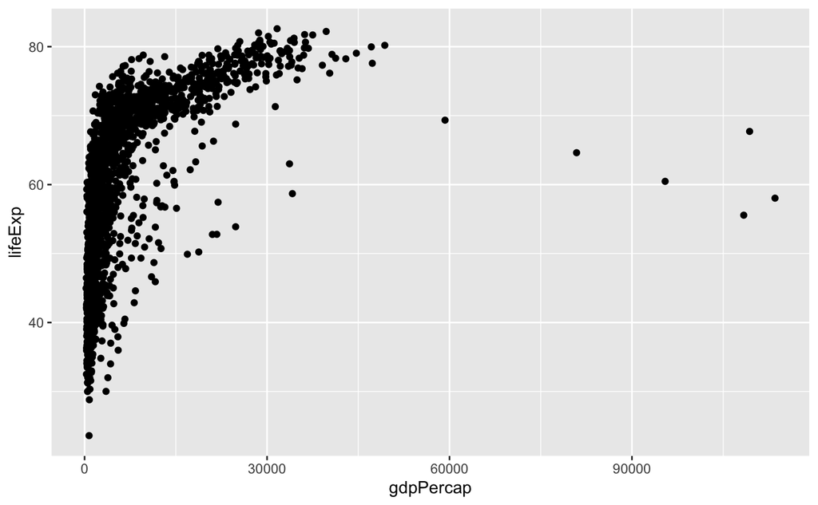

## ggplot: layer by layer

- tell ggplot() what the data is
- tell ggplot() what relationships we want to see
- tell ggplot() how we want to see the relationships
- layer other geoms as needed
- use additional functions to adjust labels, scales, and other details

## Smooth line code

```r
plot<-ggplot(data=gap,
          mapping = aes(x=gdpPercap, y=lifeExp)) +
  geom_point() +
  geom_smooth()

plot
```

## linear model smooth

```r
plot<-ggplot(data=gap,
          mapping = aes(x=gdpPercap, y=lifeExp)) +
  geom_point() +
  geom_smooth(method="lm")

plot
```

## Changing the x-axis scale

```r
plot<-ggplot(data=gap,
          mapping = aes(x=gdpPercap, y=lifeExp)) +
  geom_point() +
  geom_smooth() +
  scale_x_log10()
plot
```

## Changing the x-axis scale representation

```r
plot<-ggplot(data=gap,
          mapping = aes(x=gdpPercap, y=lifeExp)) +
  geom_point() +
  geom_smooth() +
  scale_x_log10(labels=scales::dollar)

plot
```

## trying to set the color

```r
plot<-ggplot(data=gap,
          mapping = aes(x=gdpPercap,
                        y=lifeExp,
                        color=continent)) +
  geom_point() +
  scale_x_log10(labels=scales::dollar)

plot
```

## Changing point colours

```r
plot<-ggplot(data=gap,
          mapping = aes(x=gdpPercap,
                        y=lifeExp)) +
  geom_point(color="purple", alpha=0.3) +
  geom_smooth(method="loess") +
  scale_x_log10(labels=scales::dollar)

plot
```

## More command methods

```r
plot<-ggplot(data=gap,
          mapping = aes(x=gdpPercap,
                        y=lifeExp,
                        color=continent)) +
  geom_point(alpha=0.3) +
  geom_smooth(method="lm",
              se=FALSE,
              color="orange",
              size=3) +
  scale_x_log10(labels=scales::dollar)

plot
```

## Adding labels

[figure not shown]

## specific mappings

```r
plot<-ggplot(data=gap,
          mapping = aes(x=gdpPercap,
                        y=lifeExp)) +
  geom_point(alpha=0.3,
             aes(color=continent)) +
  geom_smooth(method="gam",
              color="black") +
  scale_x_log10(labels=scales::dollar) +
  scale_y_continuous(breaks = seq(0,100,10), limits = c(0,100)) +
  labs(x= "GDP Per Capita",
       y = "Life Expectancy In Years",
       title="Economic Growth And Life Expectancy",
       subtitle="Data points represent country-years",
       caption="Source: Gapminder.") +
  theme_minimal() +
  theme(legend.position = "bottom",
        panel.grid.minor.x = element_blank(),
        axis.text.x = element_text(angle = 45, hjust = 1),
        plot.title = element_text(face = "bold", size = rel(1.5)),
        plot.subtitle = element_text(color = "grey60"),
        plot.caption = element_text(color = "grey60"),
        panel.border = element_blank(),
        panel.grid.minor = element_blank(),
        axis.line = element_line(colour = "black"))

plot
```

## Grouped data and line charts

```r
plot<-ggplot(data=gap,
          mapping = aes(x=year,
                        y=gdpPercap)) +
  geom_line(aes(group=country))

plot
```

## Facet wrapping a plot

```r
plot<-ggplot(data=gap,
          mapping = aes(x=year,
                        y=gdpPercap)) +
  geom_line(aes(group=country)) +
  geom_smooth(size = 1.1, method="loess", se=FALSE) +
  facet_wrap(~continent) +
  labs(x="Year",
       y="GDP per capita",
       title="GDP per capita on Five continents")

plot
```

## Scales, Guides, Themes

- scales = the x and y axis scales (scale_ functions)
- guides = the legends for the scales (guides() function)
- themes = all other visual elements of a figure

## Other interesting plots in ggplot

**bar plots**

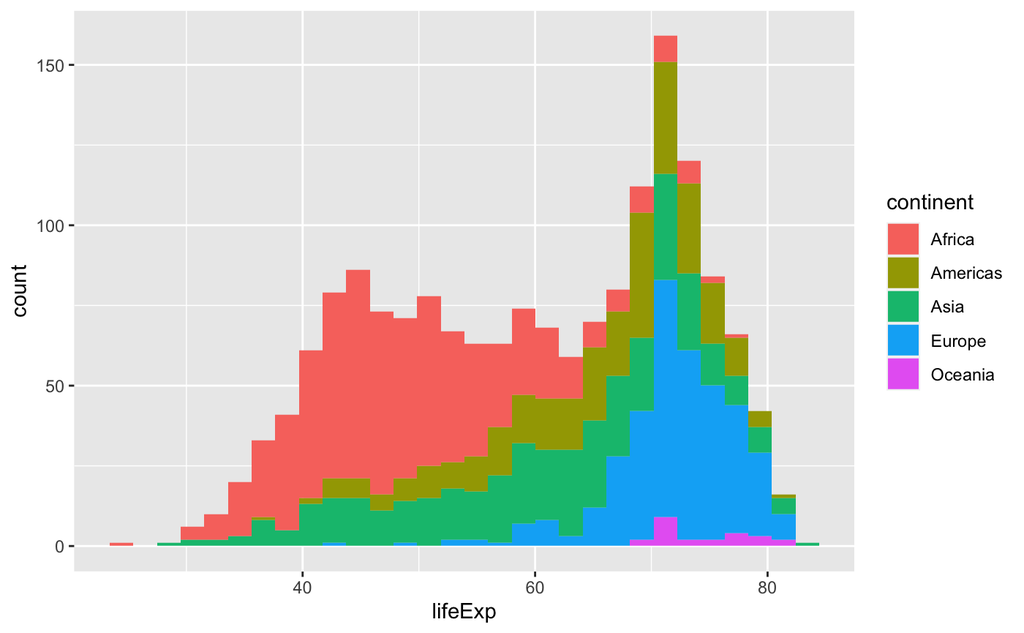

```r
# with color representing regions
ggplot(data = gap, aes(x = lifeExp, fill = continent)) +
  geom_bar(stat="bin")
```

**box plots**

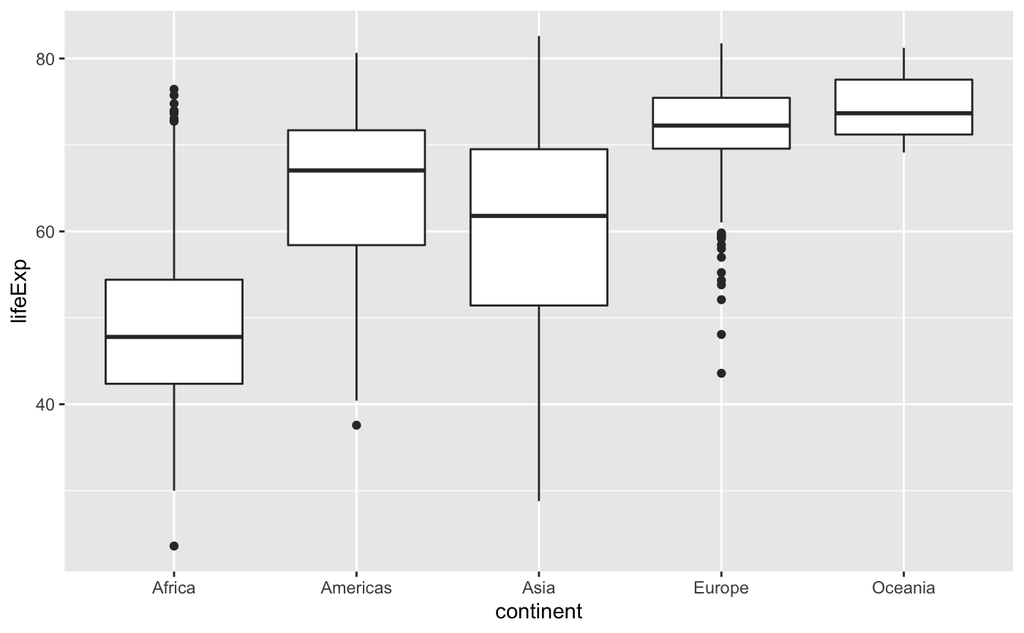

```r
ggplot(data = gap, aes(x = continent, y = lifeExp)) +
  geom_boxplot()
```

## ggpol

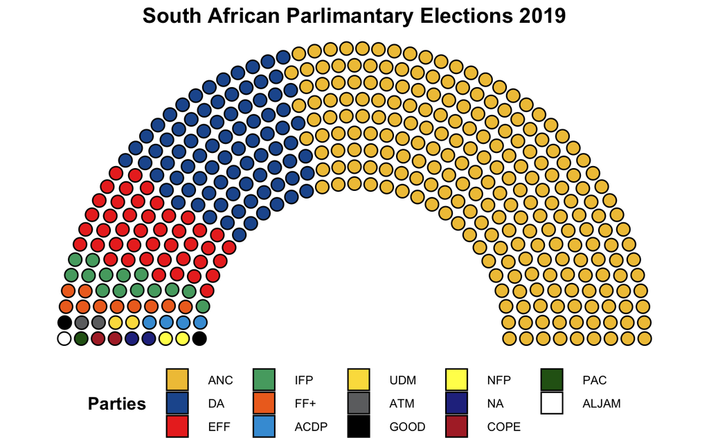

## GGPubr

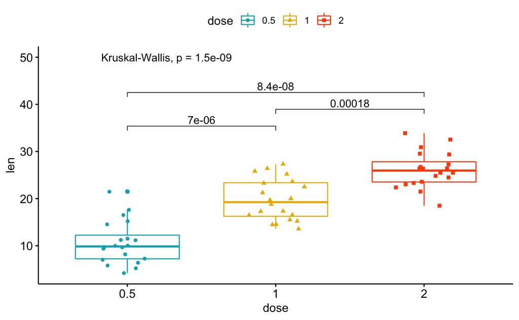

## GGPubr

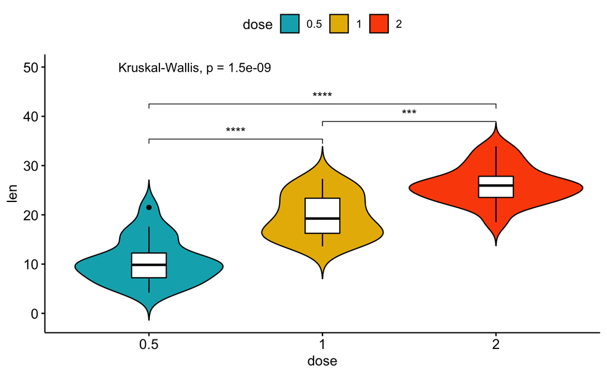

## Where to next - resources?

workshop: https://www.youtube.com/watch?v=h29g21z0a68

https://www.rstudio.com/wp-content/uploads/2015/03/ggplot2-cheatsheet.pdf

http://r-statistics.co/Top50-Ggplot2-Visualizations-MasterList-R-Code.html

http://www.cookbook-r.com/Graphs/#graphs-with-ggplot2